# An Overview of Time Series Tools in R

Econometrics - ECON 426

## Time series data

- Two features of time-series data to consider:
  1. Time-series observations on a given economic unit, observed over a number of time periods, are likely to be correlated
  2. Time-series data have a natural ordering according to time
- There is also the possible existence of dynamic relationships between variables
  - A dynamic relationship is one in which the change in a variable now has an impact on that same variable, or other variables, in one or more future time periods
  - These effects do not occur instantaneously but are spread, or distributed, over future time periods

## The distributed lag effect

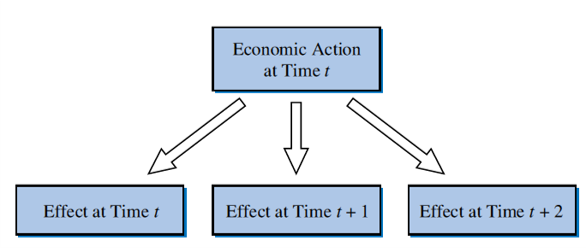

## The first big challenge

- A classical assumption of linear regression is \[{\mathop{\rm cov}} \left( {{y_i},{y_j}} \right) = {\mathop{\rm cov}} \left( {{e_i},{e_j}} \right) = 0{\rm{\ for\ }}i \ne j\]
- The dynamics of the underlying data generating process of most economic time series violates this assumptions

## The next big challenge: Stationarity

A stationary variable is one that is not explosive, nor trending, and nor wandering aimlessly without returning to its mean

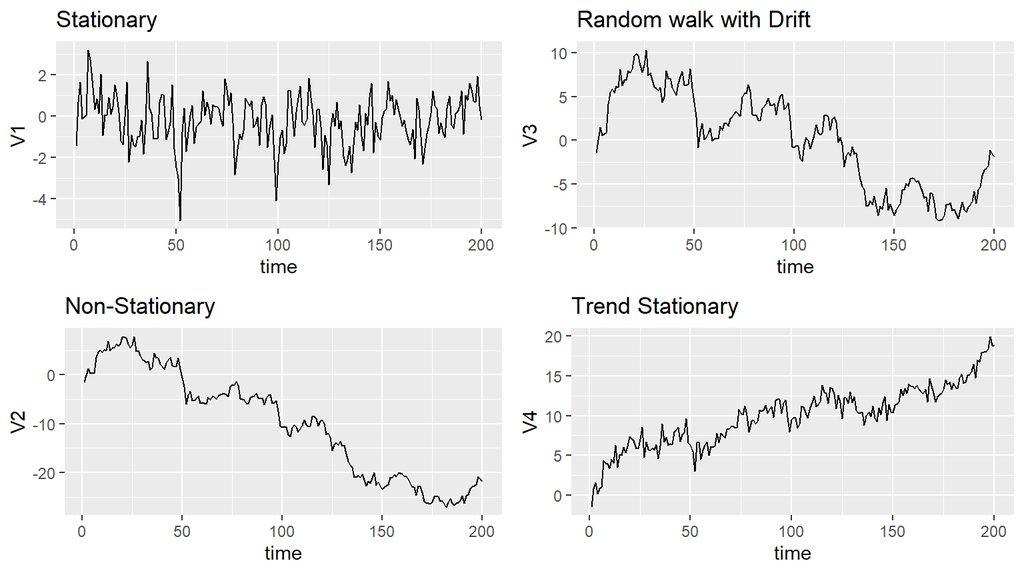

## Example: Okun’s Law

Consider Okun’s Law

- In this model the change in the unemployment rate from one period to the next depends on the rate of growth of output in the economy: \[{U_t} - {U_{t - 1}} = - \gamma \left( {{G_t} - {G_N}} \right)\]
- We can rewrite this as: \[D{U_t} = \alpha + {{\rm{\beta }}_0}{G_t} + {e_t}\\ \rm{where\ } DU_t = U_t-U_{t-1}\rm{,\ }\beta_0=-\gamma \rm{\ and\ \alpha = \gamma G_n}\]
- We can expand this to include lags: \[D{U_t} = \alpha + {{\rm{\beta }}_0}{G_t} + {{\rm{\beta }}_1}{G_{t - 1}} + {{\rm{\beta }}_2}{G_{t - 2}} + \cdots + {{\rm{\beta }}_q}{G_{t - q}} + {e_t}\]

## Example: Okun’s Law

```r
data("okun", package="PoEdata")
okun.ts <- ts(okun, start=c(1985,2), end=c(2009,3),frequency=4)

library(dynlm)
okunL3.dyn <- dynlm(d(u)~L(g, 0:3), data=okun.ts)
summ(okunL3.dyn, robust = T)
```

```
MODEL INFO:
Observations: 95
Dependent Variable: d(u)
Type: OLS linear regression

MODEL FIT:
F(4,90) = 42.23, p = 0.00
R² = 0.65
Adj. R² = 0.64

Standard errors: Robust, type = HC3
------------------------------------------------
                     Est.   S.E.   t val.      p
----------------- ------- ------ -------- ------
(Intercept)          0.58   0.08     7.61   0.00
L(g, 0:3)0          -0.20   0.03    -6.81   0.00
L(g, 0:3)1          -0.16   0.04    -4.33   0.00
L(g, 0:3)2          -0.07   0.05    -1.55   0.12
L(g, 0:3)3           0.00   0.04     0.08   0.94
------------------------------------------------
```

## Example: Okun’s Law

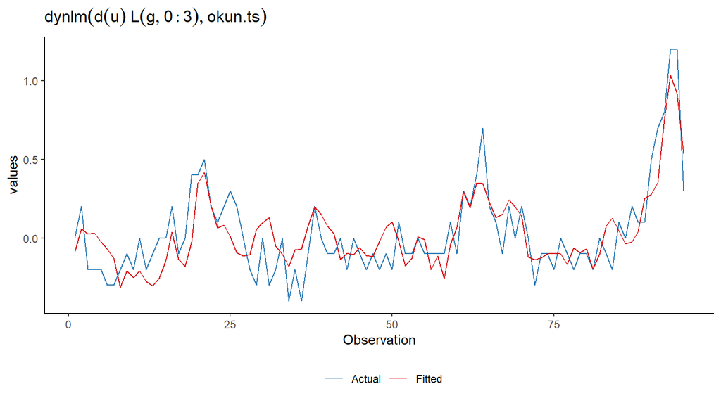

```r
plot.time(okunL3.dyn)
```

## Example: Okun’s Law

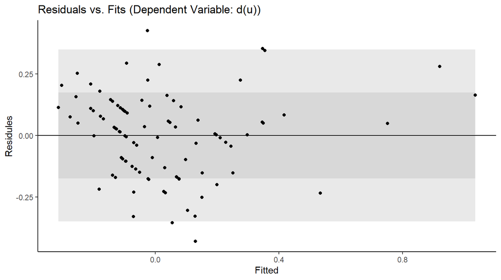

```r
plot.fitted(okunL3.dyn)
```

## You did it!

[figure not shown]